# Spotify Top Songs of the 2010s Average BPM Visualization

Clayton Greenwell

2023-07-23

### Introduction

Though this dataset was pulled from Spotify, the top songs of the 2010s (by year) were determined by Billboard. This is Billboard’s world ranking of songs for the decade, (not songs in a specific country). This dataset includes 600 songs.

Though there were many interesting tidbits of data, I’ve deleted most of it because many of the metrics seemed subjective or inconsistent. For example, I would have liked to have studied the average loudness of each song, but not enough context was given to this measurement for it to be reliable.

The variables we’re left with are the Beats Per Minute (BPM) for each song, and the year that the song was released.

First I’ll load the necessary packages:

```r
install.packages("tidyverse")
library(tidyverse)
```

### Load The Dataset

Next I’ll load the CSV file and name it “top10s”:

```r
read.csv("top10s.csv") -> top10s
```

Let’s look at the fist couple rows of data so we can make sure we have the right dataset:

```r
head(top10s)
```

```
##                  title        artist year bpm
## 1     Hey, Soul Sister         Train 2010  97
## 2 Love The Way You Lie        Eminem 2010  87
## 3              TiK ToK         Kesha 2010 120
## 4          Bad Romance     Lady Gaga 2010 119
## 5 Just the Way You Are    Bruno Mars 2010 109
## 6                 Baby Justin Bieber 2010  65
```

### Fixing “Years” Column

Next we’ll fix the *years* column so that the data is stored as a **Date** instead of a **Number**:

```r
top10s$year <- as.Date(paste0(top10s$year, "-01-01"))
```

### Data Visualization

Let’s take the average BPM of each year’s songs and visualize this on a line graph across all 10 years:

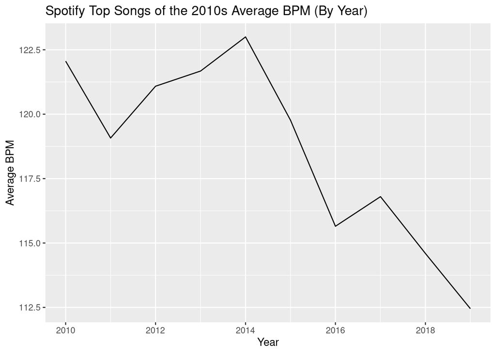

```r
ggplot(top10s, aes(x = year, y = bpm)) +
  geom_line(stat = "summary", fun = "mean") +
  labs(title = "Spotify Top Songs of the 2010s Average BPM (By Year)", x = "Year", y = "Average BPM")
```

### Conclusion

Note that the Average BPM peaked in 2014, but then trended sharply downward for the rest of the decade. This means that toward the end of the decade, slower songs were seeing more popularity.